# Independent Week 13

Christine Kandeo

1/31/2022

# Specific Data Analytics Question

Analyzing Customer Intention based on online transactions in a one year duration and Clustering the groups to identify which customers are more likely to generate revenue.

# Metrics for Success

Building a model that accurately groups whether a shopper is a paying customer based on the available features.

# Understanding the Context

Kira Plastinina is a Russian brand that is sold through a defunct chain of retail stores in Russia, Ukraine, Kazakhstan, Belarus, China, Philippines, and Armenia. The brand’s Sales and Marketing team would like to understand their customer’s behavior from data that they have collected over the past year. More specifically, they would like to learn the characteristics of customer groups.

# Experimental Design.

1.Data Preparation

- Loading the dataset
- Data Uniformity
- Handling Missing/Duplicate Values
- Checking Outliers

2.Exploratory Data Analysis

- Univariate Analysis
- Bivariate Analysis

3.Modelling

4.Conclusions and Recommendations

# Data Relevance

- Administrative, Administrative Duration, Informational, Informational Duration, Product Related and Product Related Duration - Number of different types of pages visited by the visitor in that session and total time spent in each of these page categories
- Bounce Rate - Percentage of visitors who enter the site from the page then leave (“bounce”) without triggering any other requests to the analytics server during that session
- Exit Rate - Percentage that were the last in the session
- Page Value - Average value for a web page that a user visited before completing an e-commerce transaction
- Special Day - Closeness of the site visiting time to a specific special day (e.g. Mother’s Day, Valentine’s Day) in which the sessions are more likely to be finalized with transaction
- Month - Month of the year
- Operating system,browser, region, traffic type - Different types of operating systems, browser, region and traffic type used to visit the website
- Visitor type - Whether the customer is returning or a new visitor
- Weekend - Boolean value indicating whether the date of the visit is weekend
- Revenue - Class whether it can make a revenue or not. {Class Label}

# 1. Data Preparation

Loading Libraries

```r
#Loading dependencies:
library(tidyverse)
library(scales)
library(psych)
library(mlr)
```

```r
library(grid)
library(ggplot2)
library(gridExtra)
library(crosstable)
library(GGally)
#For visualization:
library(ggcorrplot)


#For copying the data:
library(data.table)
#For Label Encoding
library(superml)
#For Clustering:
library(factoextra)
library("ggdendro")
library(flashClust)
library(caret)
```

Loading the Dataset

```r
#Importing the data to the Global Environment:
Online <- read.csv("http://bit.ly/EcommerceCustomersDataset", header = TRUE, sep = ",")

#Printing the first 4 rows of the dataframe
head(Online, n=4)
```

```
##   Administrative Administrative_Duration Informational Informational_Duration
## 1              0                       0             0                      0
## 2              0                       0             0                      0
## 3              0                      -1             0                     -1
## 4              0                       0             0                      0
##   ProductRelated ProductRelated_Duration BounceRates ExitRates PageValues
## 1              1                0.000000        0.20      0.20          0
## 2              2               64.000000        0.00      0.10          0
## 3              1               -1.000000        0.20      0.20          0
## 4              2                2.666667        0.05      0.14          0
##   SpecialDay Month OperatingSystems Browser Region TrafficType
## 1          0   Feb                1       1      1           1
## 2          0   Feb                2       2      1           2
## 3          0   Feb                4       1      9           3
## 4          0   Feb                3       2      2           4
##         VisitorType Weekend Revenue
## 1 Returning_Visitor   FALSE   FALSE
## 2 Returning_Visitor   FALSE   FALSE
## 3 Returning_Visitor   FALSE   FALSE
## 4 Returning_Visitor   FALSE   FALSE
```

```r
#Checking the Number of Rows and Columns:
dim(Online)
```

```
## [1] 12330    18
```

The Dataset is made up of 12,330 Rows and 18 Columns

Data Uniformity

```r
#Getting Information on the data types on each respective column:
sapply(Online, class)
```

```
##          Administrative Administrative_Duration           Informational
##               "integer"               "numeric"               "integer"
##  Informational_Duration          ProductRelated ProductRelated_Duration
##               "numeric"               "integer"               "numeric"
##             BounceRates               ExitRates              PageValues
##               "numeric"               "numeric"               "numeric"
##              SpecialDay                   Month        OperatingSystems
##               "numeric"             "character"               "integer"
##                 Browser                  Region             TrafficType
##               "integer"               "integer"               "integer"
##             VisitorType                 Weekend                 Revenue
##             "character"               "logical"               "logical"
```

```r
#Viewing the full information:
str(Online)
```

```
## 'data.frame':    12330 obs. of  18 variables:
##  $ Administrative         : int  0 0 0 0 0 0 0 1 0 0 ...
##  $ Administrative_Duration: num  0 0 -1 0 0 0 -1 -1 0 0 ...
##  $ Informational          : int  0 0 0 0 0 0 0 0 0 0 ...
##  $ Informational_Duration : num  0 0 -1 0 0 0 -1 -1 0 0 ...
##  $ ProductRelated         : int  1 2 1 2 10 19 1 1 2 3 ...
##  $ ProductRelated_Duration: num  0 64 -1 2.67 627.5 ...
##  $ BounceRates            : num  0.2 0 0.2 0.05 0.02 ...
##  $ ExitRates              : num  0.2 0.1 0.2 0.14 0.05 ...
##  $ PageValues             : num  0 0 0 0 0 0 0 0 0 0 ...
##  $ SpecialDay             : num  0 0 0 0 0 0 0.4 0 0.8 0.4 ...
##  $ Month                  : chr  "Feb" "Feb" "Feb" "Feb" ...
##  $ OperatingSystems       : int  1 2 4 3 3 2 2 1 2 2 ...
##  $ Browser                : int  1 2 1 2 3 2 4 2 2 4 ...
##  $ Region                 : int  1 1 9 2 1 1 3 1 2 1 ...
##  $ TrafficType            : int  1 2 3 4 4 3 3 5 3 2 ...
##  $ VisitorType            : chr  "Returning_Visitor" "Returning_Visitor" "Returning_Visitor" "Returning_Visitor" ...
##  $ Weekend                : logi  FALSE FALSE FALSE FALSE TRUE FALSE ...
##  $ Revenue                : logi  FALSE FALSE FALSE FALSE FALSE FALSE ...
```

Missing Values

```r
#Checking for null entries in each column:
colSums(is.na(Online))
```

```
##          Administrative Administrative_Duration           Informational
##                      14                      14                      14
##  Informational_Duration          ProductRelated ProductRelated_Duration
##                      14                      14                      14
##             BounceRates               ExitRates              PageValues
##                      14                      14                       0
##              SpecialDay                   Month        OperatingSystems
##                       0                       0                       0
##                 Browser                  Region             TrafficType
##                       0                       0                       0
##             VisitorType                 Weekend                 Revenue
##                       0                       0                       0
```

```r
#For the entire data set:
sum(is.na(Online))
```

```
## [1] 112
```

The dataset has 112 missing values

Since this samples represents a small portion of the total dataset, the missing observations are dropped.

Handling Missing Values

```r
#Dropping the missing values in the first 8 columns:
Online <- na.omit(Online)

#Confirming that the missing values have been dropped:
sum(is.na(Online))
```

```
## [1] 0
```

Duplicate values

```r
#Checking for identical entries:
sum(duplicated(Online))
```

```
## [1] 117
```

The dataset has 117 identical entries

Handling Duplicate Values

```r
#Dropping the duplicated entries:
Online <- Online[!duplicated(Online), ]

#Alternatively:
#Online = distinct(Online)

#Confirming the duplicates have been dropped:
any(duplicated(Online))
```

```
## [1] FALSE
```

Checking for Outliers

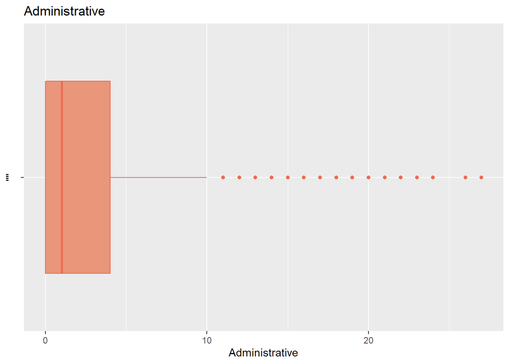

```r
#Using a Box plot to check for outliers on the numerical variables:

#1. Integer columns: Administrative, Informational, Product Related, Operating system, Browser, Region and Traffic Type:
qplot( x =  Administrative, y = "", geom = "boxplot", data = Online, col = I("coral2"), fill = I("darksalmon"), main = "Administrative ")
```

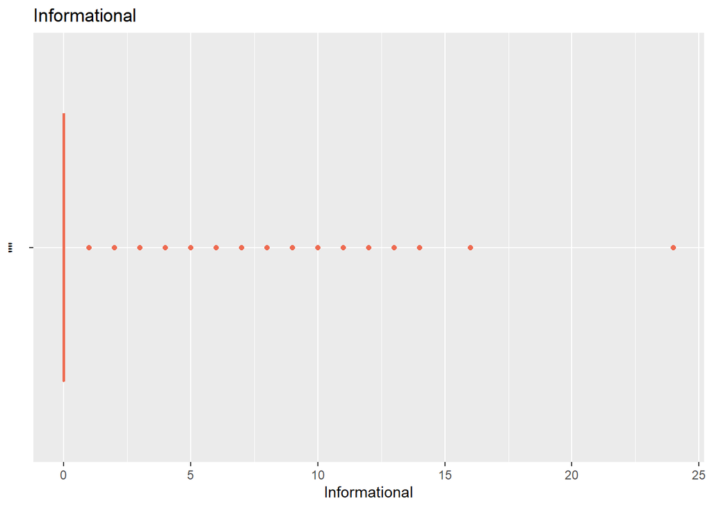

```r
qplot( x =  Informational, y = "", geom = "boxplot", data = Online, col = I("coral2"), fill = I("darksalmon"), main = "Informational")
```

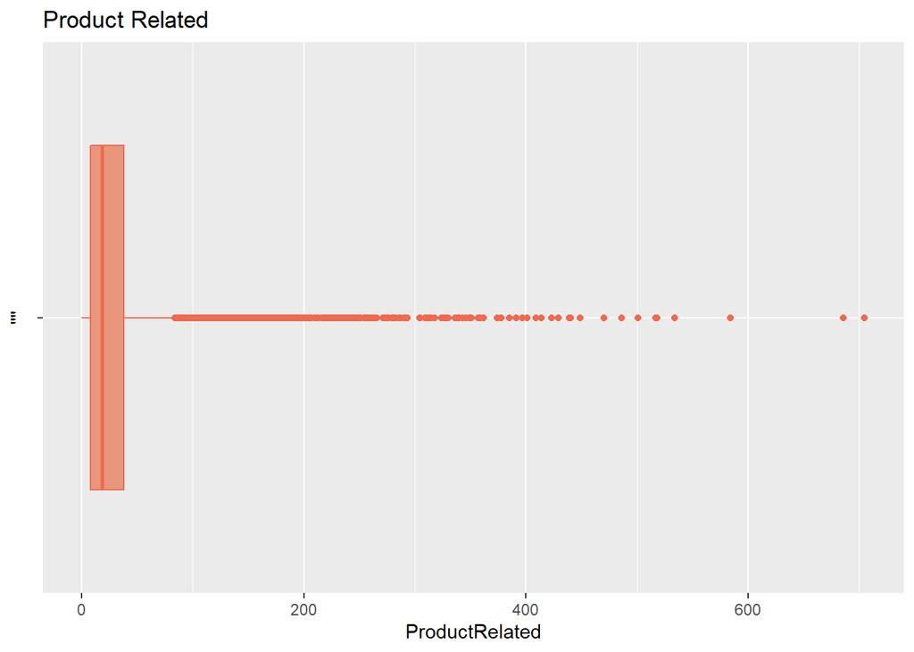

```r
qplot( x =  ProductRelated, y = "", geom = "boxplot", data = Online ,col = I("coral2"), fill = I("darksalmon"), main = "Product Related")
```

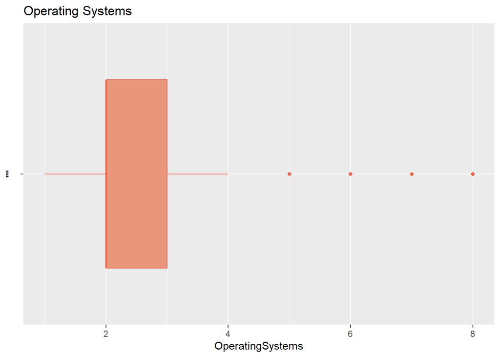

```r
qplot( x =  OperatingSystems, y = "", geom = "boxplot", data = Online, col = I("coral2"), fill = I("darksalmon"), main = "Operating Systems")
```

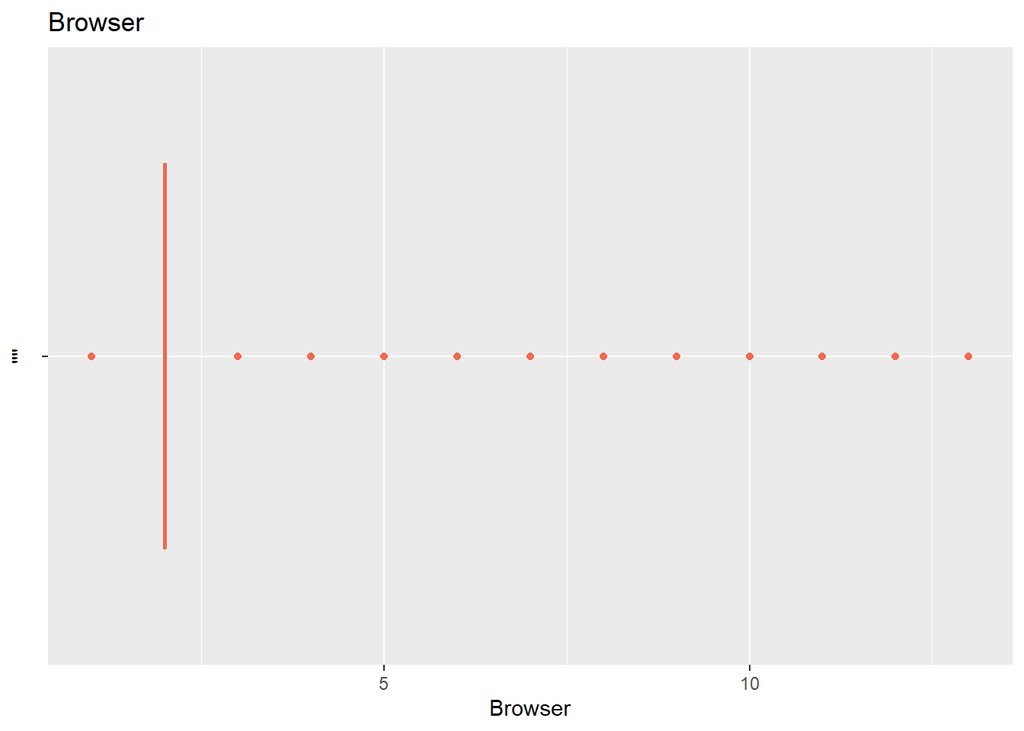

```r
qplot( x =  Browser, y = "", geom = "boxplot", data = Online, col = I("coral2"), fill = I("darksalmon"), main = "Browser")
```

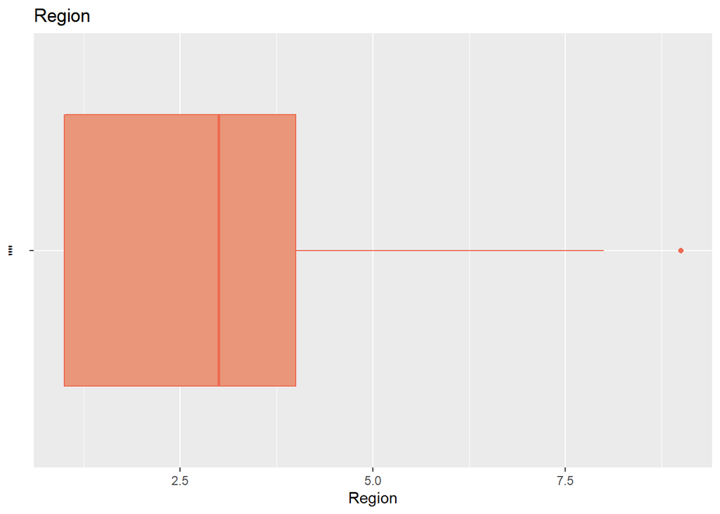

```r
qplot( x =  Region, y = "", geom = "boxplot", data = Online ,col = I("coral2"), fill = I("darksalmon"), main = "Region")
```

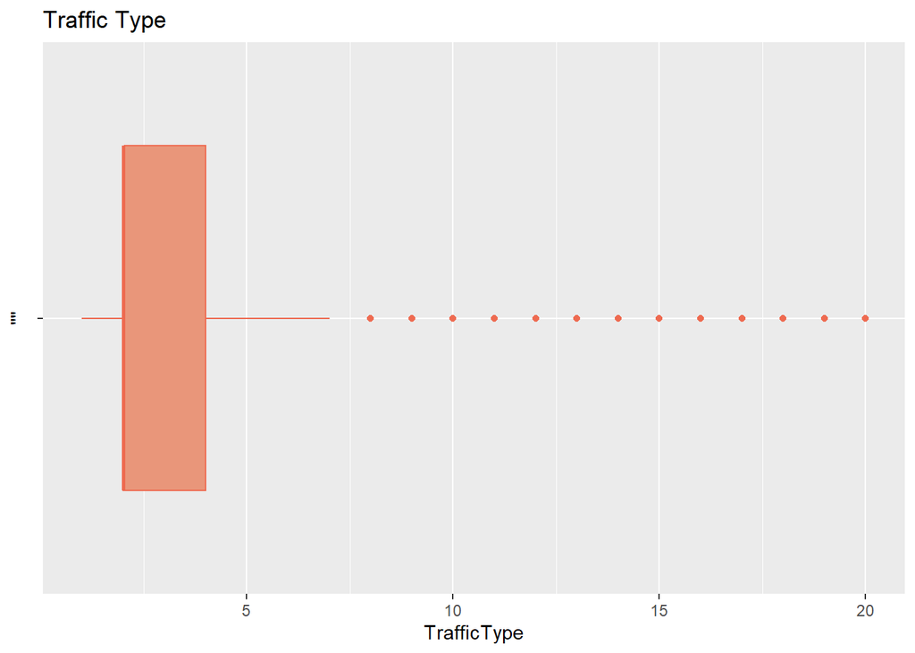

```r
qplot( x = TrafficType,  y = "", geom = "boxplot", data = Online ,col = I("coral2"), fill = I("darksalmon"), main = "Traffic Type")
```

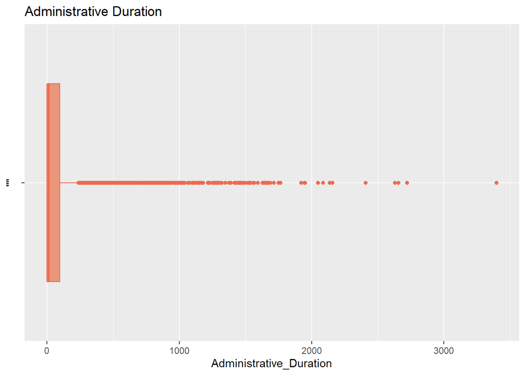

```r
#2. Numeric columns: Administrative Duration, Informational Duration, Product Related Duration, Bounce Rates, Exit Rates, Page Values and Special Day:
qplot( x =  Administrative_Duration, y = "", geom = "boxplot", data = Online, col = I("coral2"), fill = I("darksalmon"), main = "Administrative Duration ")
```

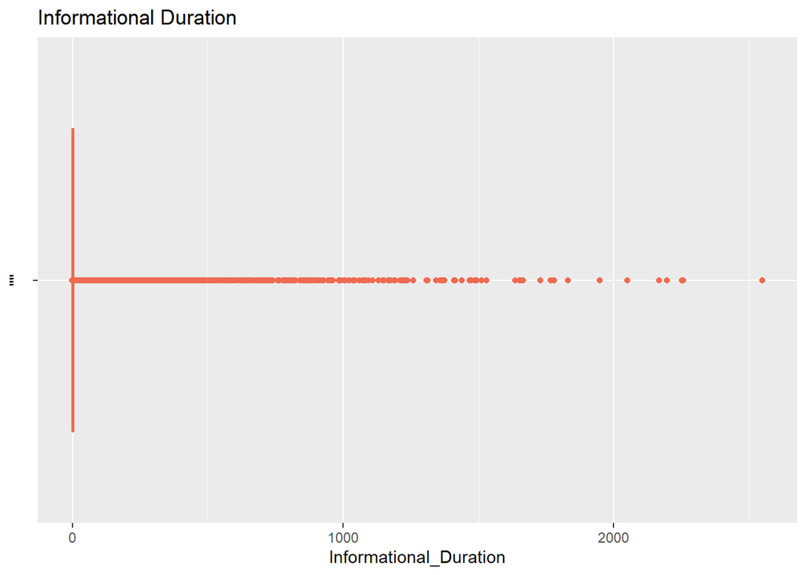

```r
qplot( x =  Informational_Duration, y = "", geom = "boxplot", data = Online, col = I("coral2"), fill = I("darksalmon"), main = "Informational Duration")
```

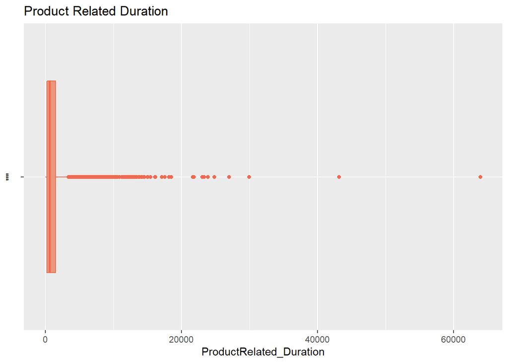

```r
qplot( x =  ProductRelated_Duration, y = "", geom = "boxplot", data = Online ,col = I("coral2"), fill = I("darksalmon"), main = "Product Related Duration")
```

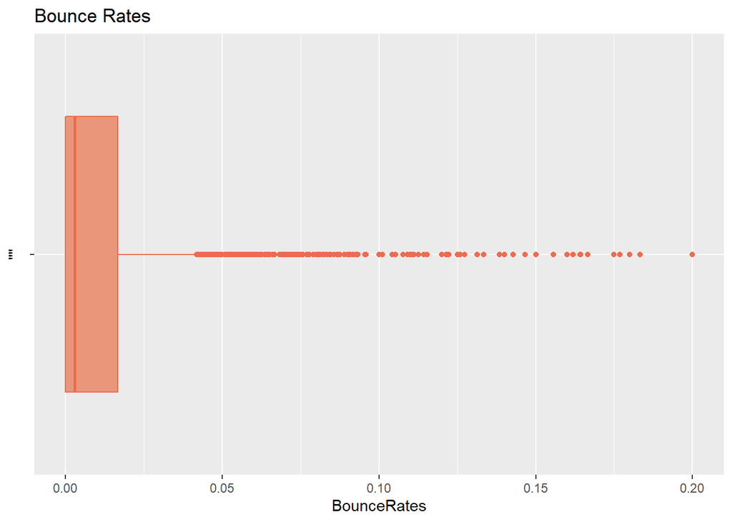

```r
qplot( x =  BounceRates, y = "", geom = "boxplot", data = Online, col = I("coral2"), fill = I("darksalmon"), main = "Bounce Rates")
```

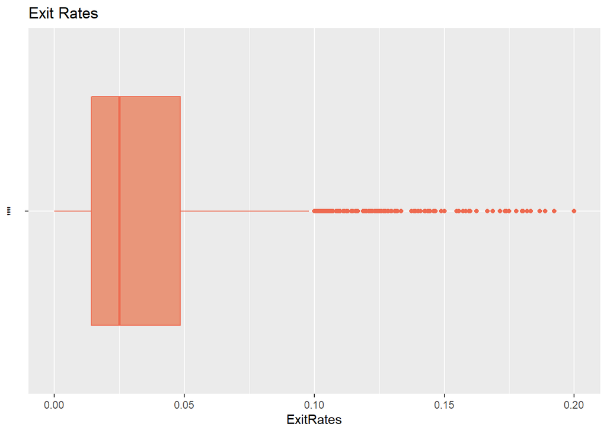

```r
qplot( x =  ExitRates, y = "", geom = "boxplot", data = Online, col = I("coral2"), fill = I("darksalmon"), main = "Exit Rates")
```

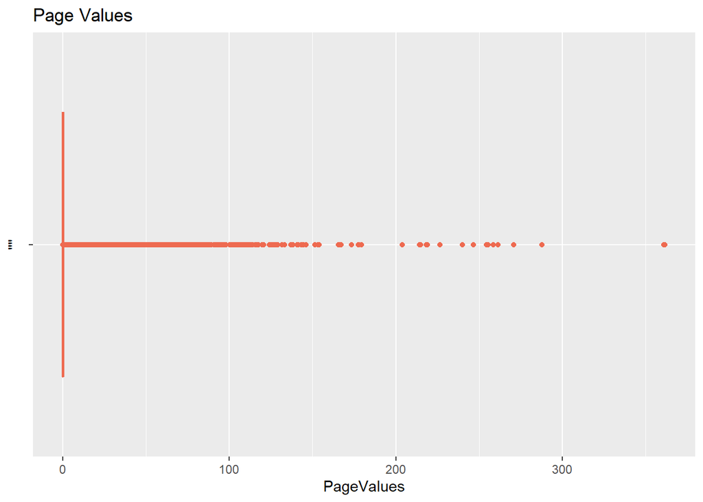

```r
qplot( x =  PageValues, y = "", geom = "boxplot", data = Online ,col = I("coral2"), fill = I("darksalmon"), main = "Page Values")
```

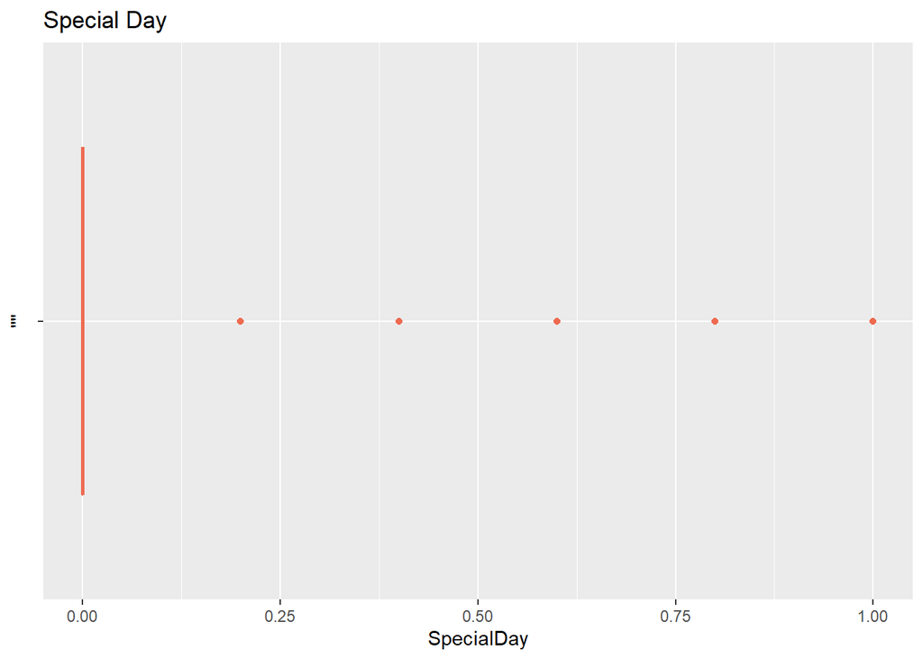

```r
qplot( x = SpecialDay,  y = "", geom = "boxplot", data = Online ,col = I("coral2"), fill = I("darksalmon"), main = "Special Day")
```

From the Plots above:

Outliers can be observed in all the Continuous Variables. Since there’s no basis to assume the entries are not valid observations, no outliers are dropped.

# 2. Exploratory Data Analysis

This process involves investigating the dataset to discover patterns.

# Univariate Analysis

This analysis aims to explore each variable in the dataset separately

- Revenue Distribution

```r
#To view the distribution of Revenue:
Rev_table <- table(Online$Revenue)
Rev_table
```

```
##
## FALSE  TRUE
## 10291  1908
```

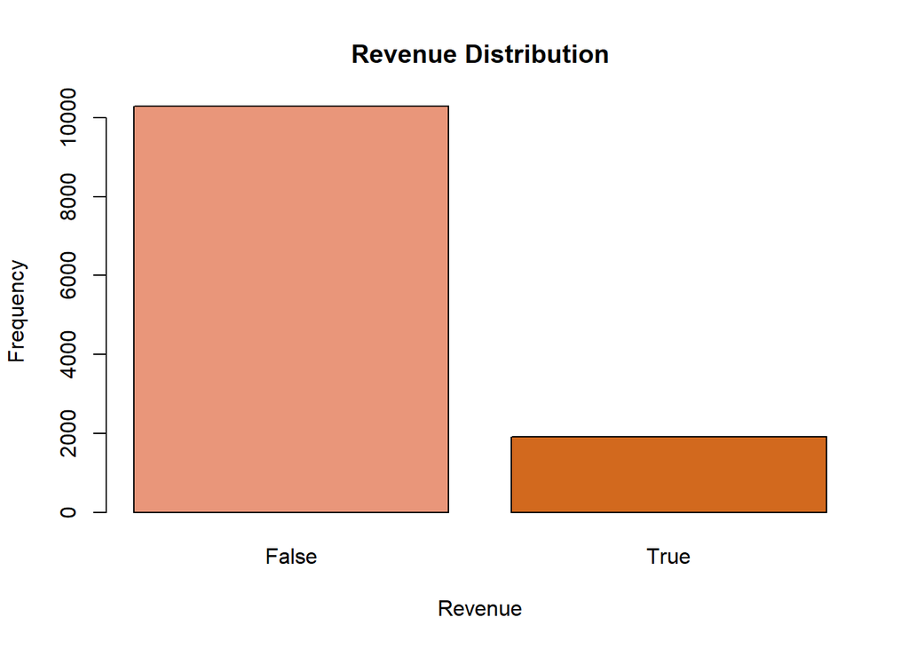

```r
#Plotting the Information above on a bar chart:
barplot(Rev_table,
main = "Revenue Distribution",
xlab = "Revenue",
ylab = "Frequency",
names.arg = c("False", "True"),
col = c("darksalmon", "chocolate"),
horiz = FALSE)
```

Of the 12,199 sessions, 10,291 were negative class samples: Those that did not end with shopping. 1,908 were the only positive samples: Those that ended with shopping.

This shows an imbalance within the target variable.

It can also be said that the site did not generate expected revenue.

- Days with Frequent Activities

```r
#To view the Type of day most sessions were logged:
Weekend_table <- table(Online$Weekend)
Weekend_table
```

```
##
## FALSE  TRUE
##  9343  2856
```

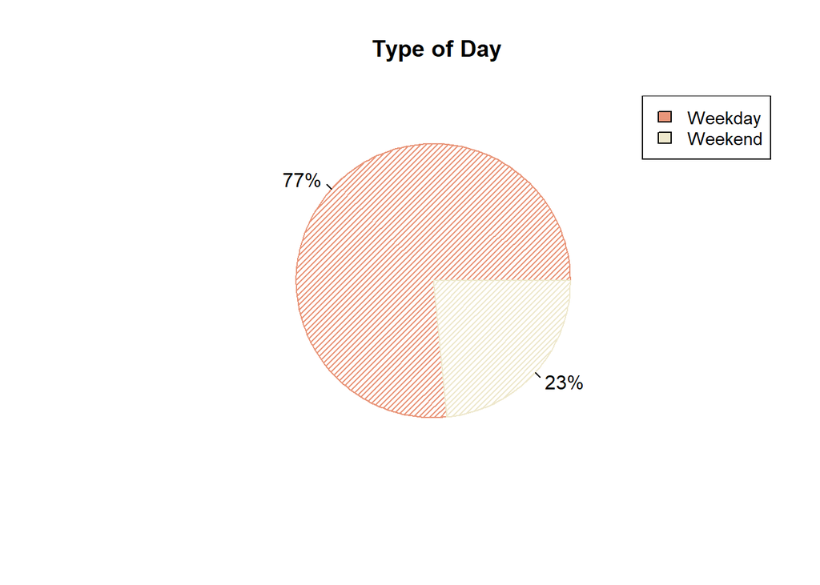

```r
#Plotting the Information above:
x <- c(76.59, 23.41)
labels <- c('False', 'True')
colors <- c('darksalmon','cornsilk2')
#pie_percent<- round(100*x/sum(x), 0)
pie(x, labels = percent(x/100), main=' Type of Day', density=30, col=colors)
legend("topright", c("Weekday", "Weekend"), cex = 0.9, fill = colors)
```

77% of the activities were done over the weekday. This can be justified with the fact that Weekdays have a 5 day period.

- Type of Visitor

```r
#To view the type of visitors visiting the site:
Visitor_table <- table(Online$VisitorType)
Visitor_table
```

```
##
##       New_Visitor             Other Returning_Visitor
##              1693                81             10425
```

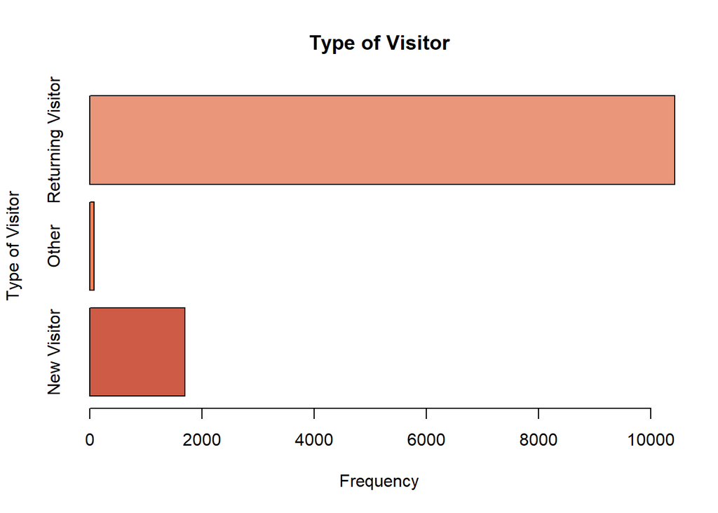

```r
#Plotting the Information above on a bar chart:
barplot(Visitor_table,
main = "Type of Visitor",
xlab = "Frequency",
ylab = "Type of Visitor",
names.arg = c("New Visitor", "Other", "Returning Visitor"),
col = c("coral3", "coral", "darksalmon"),
horiz = TRUE)
```

The vast majority of the visitors were Returning customers.

- Month Distribution

```r
#To view the monthly distribution:
Month_table <- table(Online$Month)
Month_table
```

```
##
##  Aug  Dec  Feb  Jul June  Mar  May  Nov  Oct  Sep
##  433 1706  182  432  285 1853 3328 2983  549  448
```

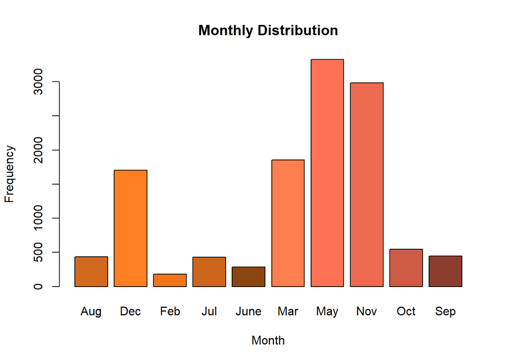

```r
#Plotting the Information above on a bar chart:
barplot(Month_table,
main = "Monthly Distribution",
xlab = "Month",
ylab = "Frequency",
names.arg = c("Aug", "Dec", "Feb", "Jul", "June", "Mar", "May", "Nov", "Oct", "Sep"),
col = c("chocolate", "chocolate1", "chocolate2", "chocolate3", "chocolate4", "coral", "coral1", "coral2", "coral3", "coral4"),
horiz = FALSE)
```

- The month column only has 10 months represented. January and April are missing.

- May and November are the months with the most User activities.
- [Online Sales](https://www.salecycle.com/blog/stats/when-are-people-most-likely-to-buy-online/) in the Month of November are considered to be the highest due to Black Friday and the Holiday seasons.
- Numerical Features

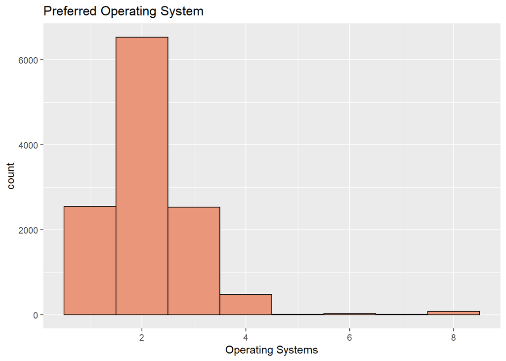

```r
#Plotting a histogram to understand the distribution of the continuous features:
#The features plotted below are Numeric but actually represent categories:
ggplot(data = Online, mapping = aes(x = OperatingSystems)) +
  geom_histogram(fill = "darksalmon", color = "black", binwidth = 1) + labs(x = "Operating Systems", title = "Preferred Operating System")
```

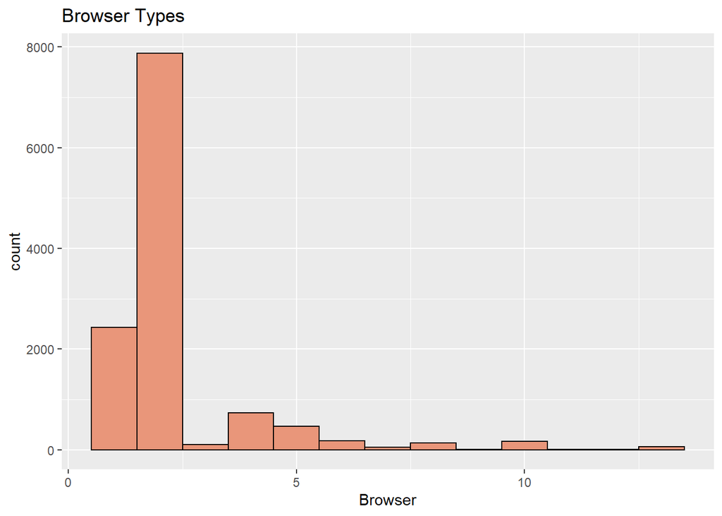

```r
ggplot(data = Online, mapping = aes(x = Browser)) +
  geom_histogram(fill = "darksalmon", color = "black", binwidth = 1) + labs(x = "Browser", title = "Browser Types")
```

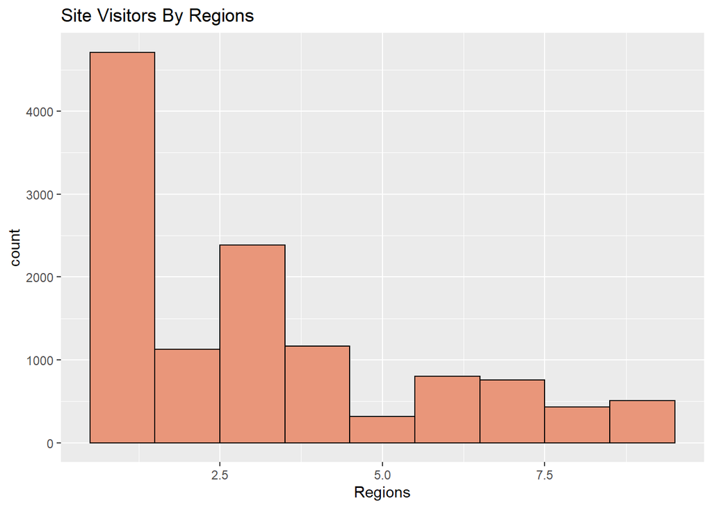

```r
ggplot(data = Online, mapping = aes(x = Region)) +
  geom_histogram(fill = "darksalmon", color = "black", binwidth = 1) + labs(x = "Regions", title = "Site Visitors By Regions")
```

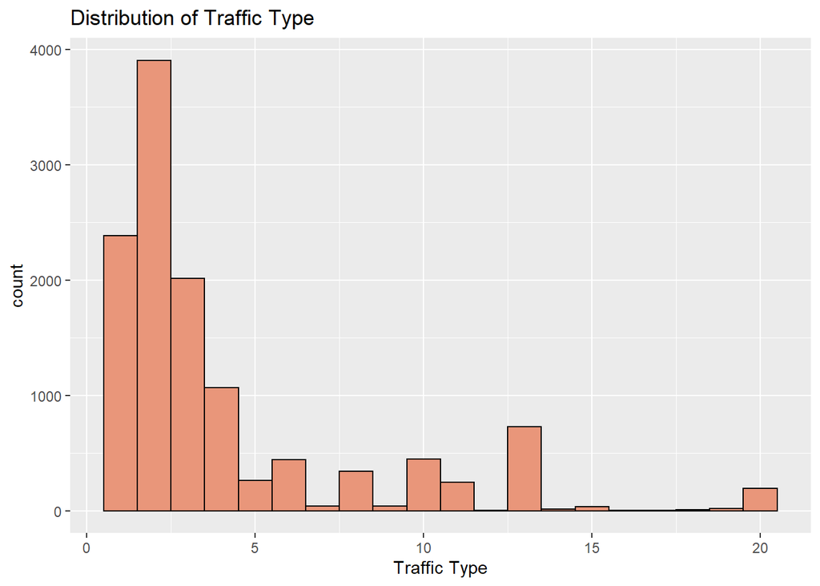

```r
ggplot(data = Online, mapping = aes(x = TrafficType)) +
  geom_histogram(fill = "darksalmon", color = "black", binwidth = 1) + labs(x = "Traffic Type", title = "Distribution of Traffic Type")
```

- Operating System: Majority of the visitors used the 2nd Operating System to visit the Website.
- Browser: The 2nd Browser was popular across the visitors accessing the Website.
- Regions: Region 1 followed by Region 3 had the most number of visitors entering the Site.
- Traffic Type: The 2nd Type of Traffic was the most popular with the visitors.

It can be observed that the distributions are all right skewed.

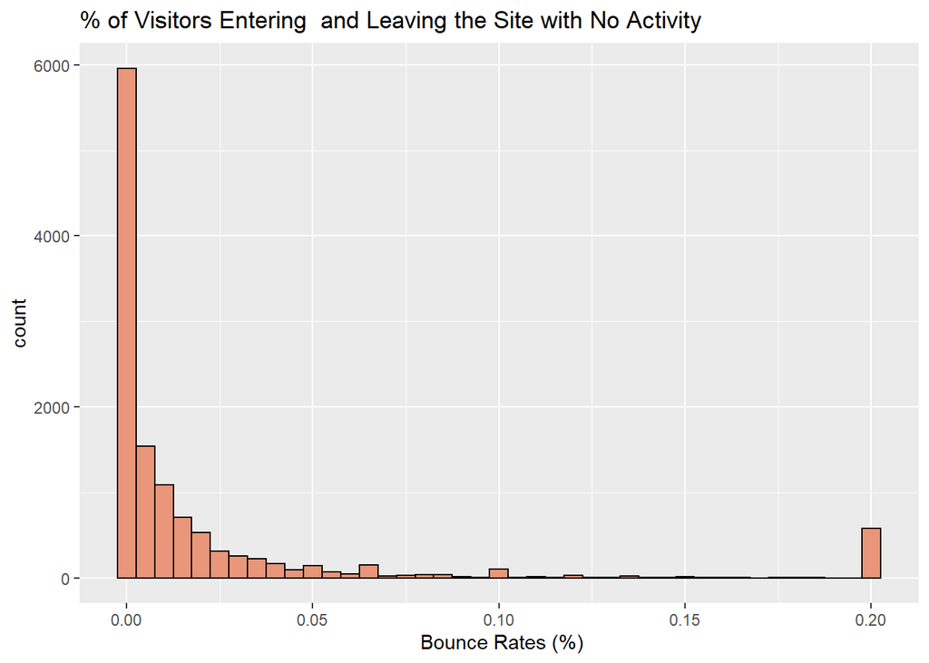

```r
#Plotting a histogram to understand the distribution of the other continuous features:
ggplot(data = Online, mapping = aes(x = BounceRates)) +
  geom_histogram(fill = "darksalmon", color = "black", binwidth = 0.005) + labs(x = " Bounce Rates (%)", title = "% of Visitors Entering  and Leaving the Site with No Activity")
```

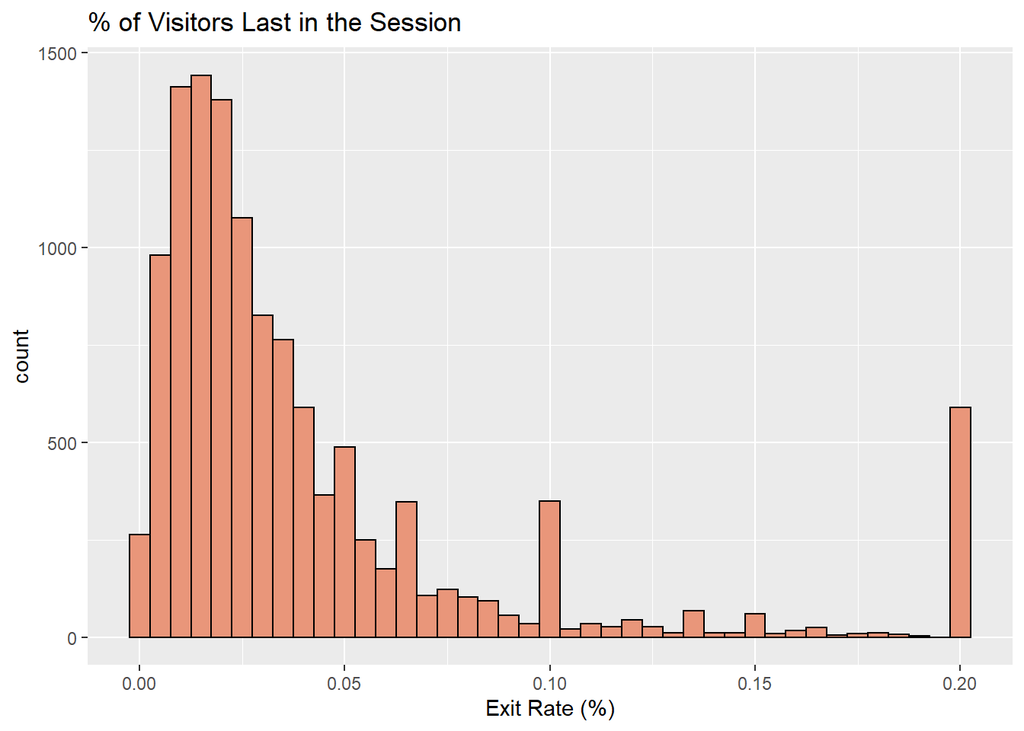

```r
ggplot(data = Online, mapping = aes(x = ExitRates)) +
  geom_histogram(fill = "darksalmon", color = "black", binwidth = 0.005) + labs(x = "Exit Rate (%)", title = "% of Visitors Last in the Session")
```

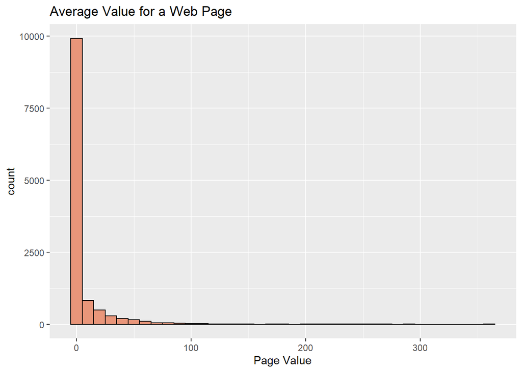

```r
ggplot(data = Online, mapping = aes(x = PageValues)) +
  geom_histogram(fill = "darksalmon", color = "black", binwidth = 10) + labs(x = "Page Value", title = "Average Value for a Web Page")
```

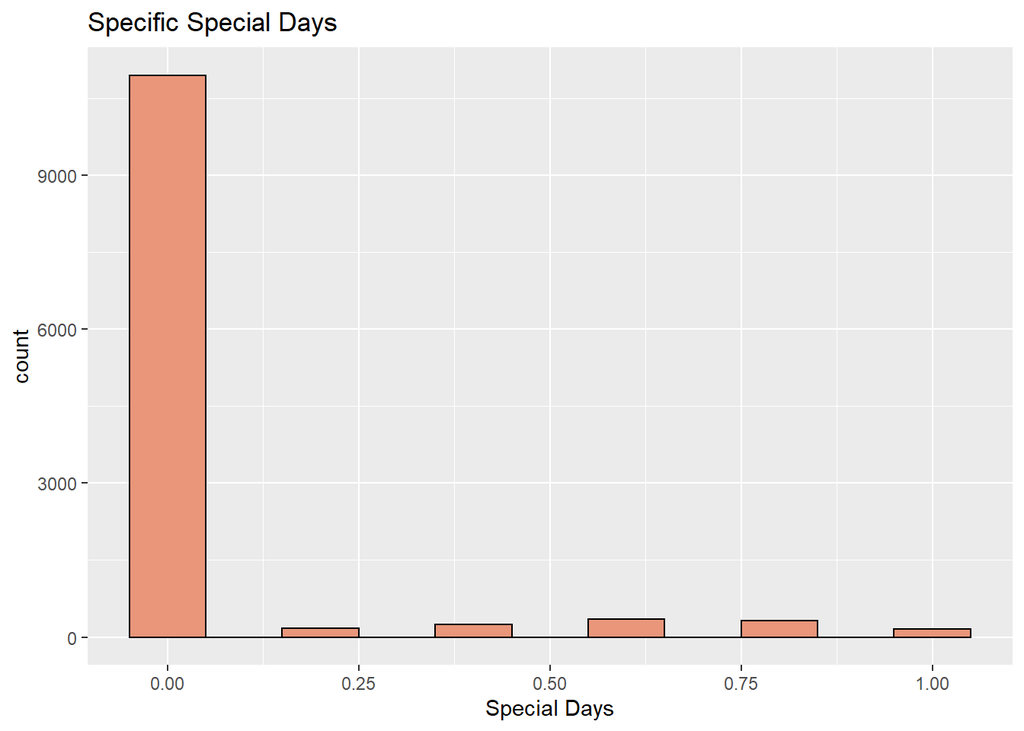

```r
ggplot(data = Online, mapping = aes(x = SpecialDay)) +
  geom_histogram(fill = "darksalmon", color = "black", binwidth = 0.1) + labs(x = "Special Days", title = "Specific Special Days")
```

- Bounce Rates: Majority of the visitors who entered the site from that page and left without any requests were between 0.00-0.05%
- Exit Rates: Those visitors that were last in the session ranged between 0.00-0.05%
- Page Values: The average value for a web page common among most of the users visited before completing a transaction was 0
- Special Days: The closeness of the site visiting time to a specific special day for the visitors was 0.
- Types Of Pages

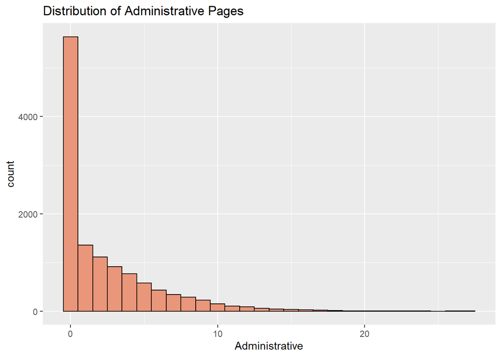

```r
#Plotting a histogram to understand the Different types of pages:
ggplot(data = Online, mapping = aes(x = Administrative)) +
  geom_histogram(fill = "darksalmon", color = "black", binwidth = 1) + labs(x = "Administrative", title = "Distribution of Administrative Pages")
```

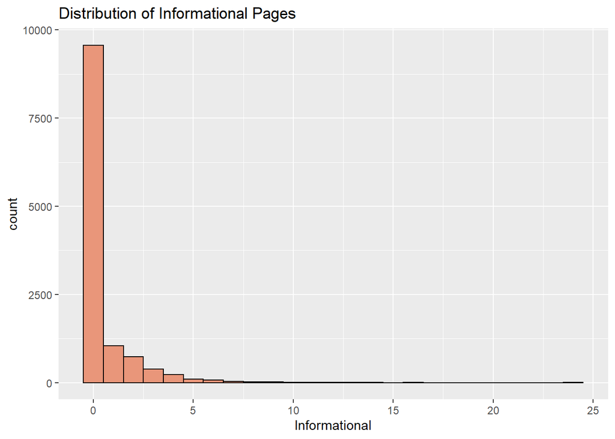

```r
ggplot(data = Online, mapping = aes(x = Informational)) +
  geom_histogram(fill = "darksalmon", color = "black", binwidth = 1) + labs(x = "Informational", title = "Distribution of Informational Pages")
```

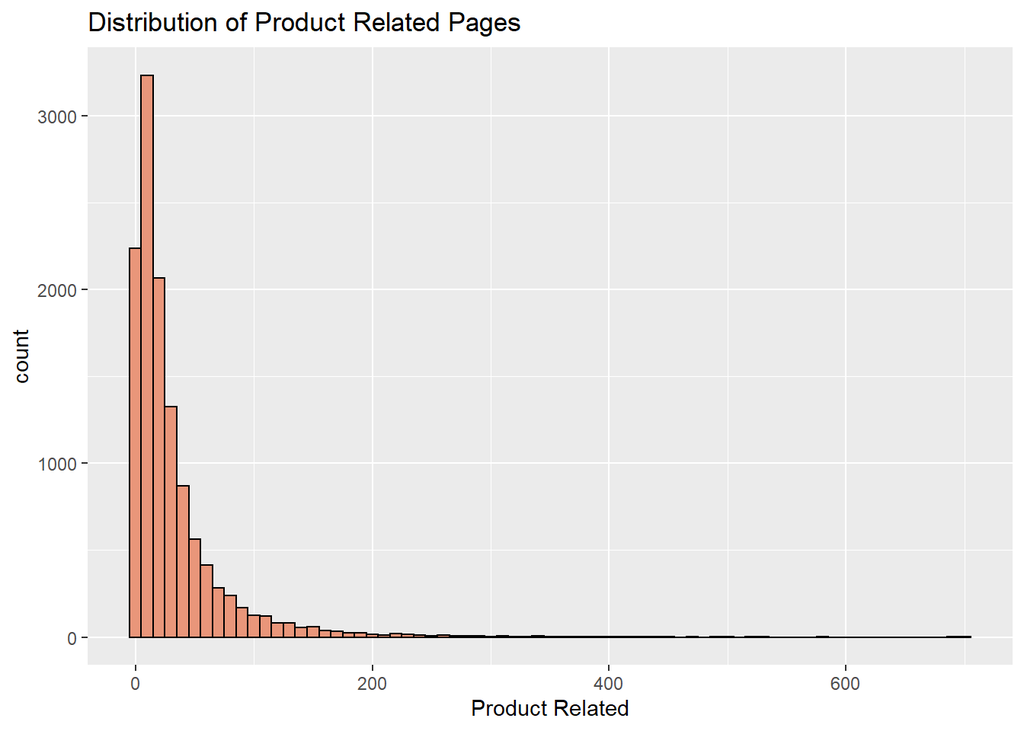

```r
ggplot(data = Online, mapping = aes(x = ProductRelated)) +
  geom_histogram(fill = "darksalmon", color = "black", binwidth = 10) + labs(x = "Product Related", title = "Distribution of Product Related Pages")
```

- Administrative: 5,637 users did not visit administrative pages.
- Informational: 9,569 users did not access any Informational page.
- Product related: 35 users did not access any Product related page. This is lower compared to the other 2 pages.

It can therefore be concluded that the vast majority visited Product related pages.

- Total Time spent on the Pages

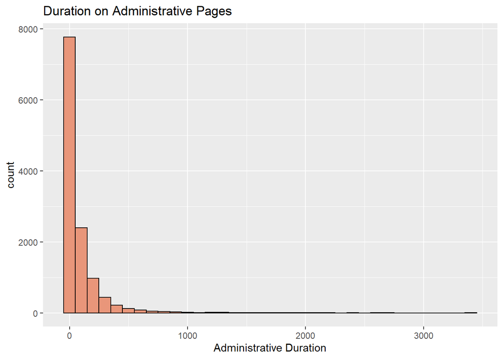

```r
#Plotting a histogram to understand the Time spent on the Different types of pages:
ggplot(data = Online, mapping = aes(x = Administrative_Duration)) +
  geom_histogram(fill = "darksalmon", color = "black", binwidth = 100) + labs(x = "Administrative Duration", title = "Duration on Administrative Pages")
```

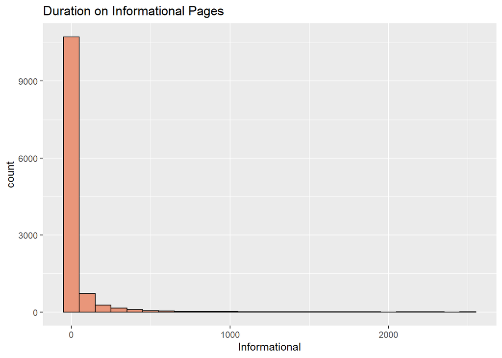

```r
ggplot(data = Online, mapping = aes(x = Informational_Duration)) +
  geom_histogram(fill = "darksalmon", color = "black", binwidth = 100) + labs(x = "Informational", title = "Duration on Informational Pages")
```

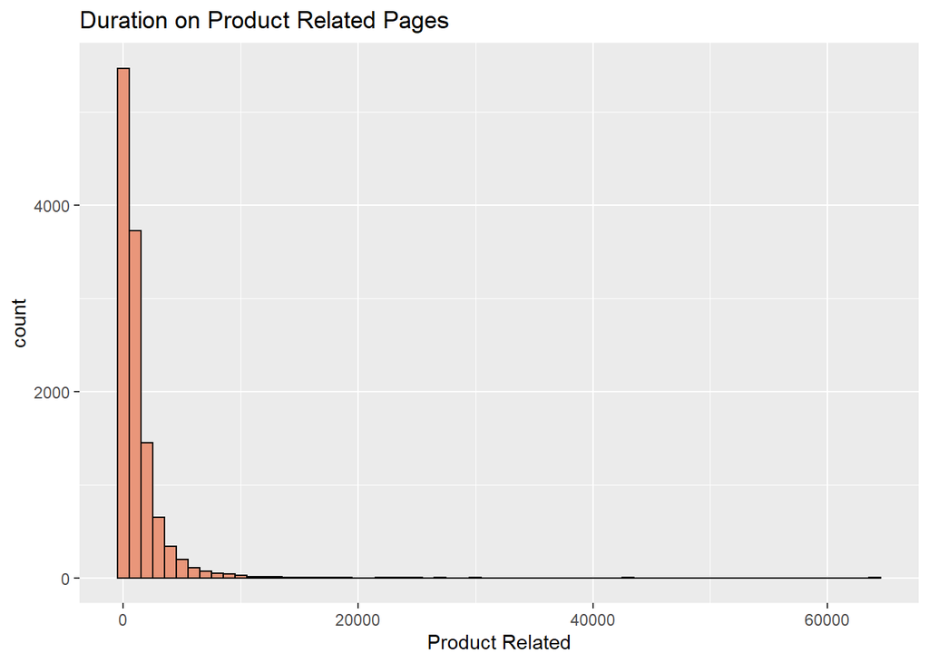

```r
ggplot(data = Online, mapping = aes(x = ProductRelated_Duration)) +
  geom_histogram(fill = "darksalmon", color = "black", binwidth = 1000) + labs(x = "Product Related", title = "Duration on Product Related Pages")
```

```r
#Printing the Descriptive Summary to understand the durations spent:
summary(Online)
```

```
##  Administrative  Administrative_Duration Informational
##  Min.   : 0.00   Min.   :  -1.00         Min.   : 0.0000
##  1st Qu.: 0.00   1st Qu.:   0.00         1st Qu.: 0.0000
##  Median : 1.00   Median :   9.00         Median : 0.0000
##  Mean   : 2.34   Mean   :  81.68         Mean   : 0.5088
##  3rd Qu.: 4.00   3rd Qu.:  94.75         3rd Qu.: 0.0000
##  Max.   :27.00   Max.   :3398.75         Max.   :24.0000
##  Informational_Duration ProductRelated   ProductRelated_Duration
##  Min.   :  -1.00        Min.   :  0.00   Min.   :   -1.0
##  1st Qu.:   0.00        1st Qu.:  8.00   1st Qu.:  193.6
##  Median :   0.00        Median : 18.00   Median :  609.5
##  Mean   :  34.84        Mean   : 32.06   Mean   : 1207.5
##  3rd Qu.:   0.00        3rd Qu.: 38.00   3rd Qu.: 1477.6
##  Max.   :2549.38        Max.   :705.00   Max.   :63973.5
##   BounceRates        ExitRates         PageValues        SpecialDay
##  Min.   :0.00000   Min.   :0.00000   Min.   :  0.000   Min.   :0.00000
##  1st Qu.:0.00000   1st Qu.:0.01422   1st Qu.:  0.000   1st Qu.:0.00000
##  Median :0.00293   Median :0.02500   Median :  0.000   Median :0.00000
##  Mean   :0.02045   Mean   :0.04150   Mean   :  5.952   Mean   :0.06197
##  3rd Qu.:0.01667   3rd Qu.:0.04848   3rd Qu.:  0.000   3rd Qu.:0.00000
##  Max.   :0.20000   Max.   :0.20000   Max.   :361.764   Max.   :1.00000
##     Month           OperatingSystems    Browser           Region
##  Length:12199       Min.   :1.000    Min.   : 1.000   Min.   :1.000
##  Class :character   1st Qu.:2.000    1st Qu.: 2.000   1st Qu.:1.000
##  Mode  :character   Median :2.000    Median : 2.000   Median :3.000
##                     Mean   :2.124    Mean   : 2.358   Mean   :3.153
##                     3rd Qu.:3.000    3rd Qu.: 2.000   3rd Qu.:4.000
##                     Max.   :8.000    Max.   :13.000   Max.   :9.000
##   TrafficType     VisitorType         Weekend         Revenue
##  Min.   : 1.000   Length:12199       Mode :logical   Mode :logical
##  1st Qu.: 2.000   Class :character   FALSE:9343      FALSE:10291
##  Median : 2.000   Mode  :character   TRUE :2856      TRUE :1908
##  Mean   : 4.075
##  3rd Qu.: 4.000
##  Max.   :20.000
```

Observations:

- Administrative Duration: The average amount of time spent on administrative pages was 82 with the maximum being 3399
- Informational Duration: The average amount of time spent on informational pages was 35 with the maximum being 2549
- Product Related Duration: The average amount of time spent on Product related pages was 1207 with the maximum being 63974
- The mean value in most categories is a lot smaller than the max value, suggesting strongly right skewed distributions of values in each category.

It can be observed that most visitors spent time on Product related pages as compared to Informational and Administrative.

The Minimum duration on Both informational and Administrative was -1. In real sense, there can be no negative time.